# Passief versus actief — en wat factorpremies daar nog aan veranderen

Een educatief onderzoeksessay

Auteur

Robbe De Win

Publicatiedatum

18 mei 2026

[figure not shown]

Persoonlijk financieel plan

18 mei 2026

Voor

# Passief versus actief — en wat factorpremies daar nog aan veranderen

Een educatief onderzoeksessay

concept

> **Leeswijzer.** Dit is een algemeen, educatief essay — geen beleggingsadvies en geen klantspecifiek plan. Alle cijfers komen uit de lokale `market_data`-store, bevroren op `as_of = 2026-05-19`, en worden één keer berekend door `notebooks/02_sensitivity.py`. De regressies gebruiken de gewone-OLS-motor van de codebase; bij overlappende rollende vensters overschat dat de significantie — de tekst zegt waar dat speelt.

## De belofte van factorbeleggen

De beleggingsindustrie verkoopt twee verhalen tegelijk. Het eerste: een goede beheerder verslaat de markt. Het tweede, wanneer het eerste niet meer overtuigt: misschien verslaat een *systematische* tilt naar bewezen factoren — small-cap, value, profitability, momentum — de markt dan wél. Dit essay neemt beide claims serieus en toetst ze met dezelfde meetlat die de rest van deze codebase gebruikt: een Fama-French-regressie op de échte rendementen van ETF’s die een Belgische particulier vandaag aanhoudt.

Begin bij het nulpunt. Sharpe (1991) formuleerde in *The Arithmetic of Active Management* een identiteit die geen enkele dataset kan weerleggen: vóór kosten is het gemiddelde actief beheerde euro per definitie gelijk aan de markt, want samen *zijn* alle beleggers de markt. Ná kosten moet de gemiddelde actieve euro de markt dus onderpresteren, en wel met precies het verschil in kosten. Dit is geen empirisch resultaat dat met betere data kan omslaan — het is rekenkunde.

De empirie bevestigt de rekenkunde onverbiddelijk. De SPIVA Europe-scorecard (S&P Dow Jones Indices, jaareinde 2024) meet welk aandeel actief beheerde Europese aandelenfondsen hun benchmark *niet* haalt, netto van kosten:

| Horizon | Aandeel actieve fondsen dat de benchmark mist |
| --- | --- |
| 1y | 55 % |
| 5y | 78 % |
| 10y | 87 % |
| 15y | 92 % |

Morningstar komt via zijn *Active/Passive Barometer* (2024) tot een spiegelbeeld: amper **14 %** van de actieve beheerders overleeft én verslaat de gemiddelde passieve concurrent over tien jaar.

Over vijftien jaar mist ruim negen op de tien fondsen de index, en het levende universum oogt door survivorship bias nog mooier dan het was.

De passieve zaak is daarmee robuust. De interessante vraag verschuift naar de tweede claim. Factorpremies zijn academisch goed gedocumenteerd: een tilt naar kleine, goedkope, winstgevende of recent sterke aandelen leverde historisch een meerrendement op dat niet door marktbeta verklaard wordt. Maar drie dingen blijven onbeantwoord, en dit essay behandelt ze elk in een eigen hoofdstuk. Eén: welke factorblootstelling dragen de concrete ETF’s van een klant écht, en hoe stabiel is die door de tijd? Twee: is de premie nog even groot als toen ze werd ontdekt, of is ze gekrompen? Drie: hoeveel van een brutopremie houdt een Belgische particulier na kosten en taksen werkelijk over? Pas als die drie vragen samen beantwoord zijn, is de factor-tilt-beslissing een rekenprobleem in plaats van een geloofskwestie.

## Van premie naar bewijslast

Om over factoren te kunnen oordelen, moeten we eerst meten. Het standaardinstrument is het vijf-factormodel van Fama & French (2015), een uitbreiding van hun driefactormodel (Fama & French 1992, 1993), aangevuld met de momentumfactor van Carhart (1997). Het regresseert het overrendement van een belegging op vijf à zes systematische bronnen:

$$R_{i,t} - R_{f,t} = \alpha_i
+ \beta_{\text{mkt}}\,(R_{m,t}-R_{f,t})
+ \beta_{\text{smb}}\,\text{SMB}_t
+ \beta_{\text{hml}}\,\text{HML}_t
+ \beta_{\text{rmw}}\,\text{RMW}_t
+ \beta_{\text{cma}}\,\text{CMA}_t
+ \beta_{\text{wml}}\,\text{WML}_t
+ \varepsilon_{i,t}$$

SMB (small-minus-big) vangt de size-tilt, HML (high-minus-low book-to-market) de value-tilt, RMW (robust-minus-weak) winstgevendheid, CMA (conservative-minus-aggressive) investeringsgedrag, en WML (winners-minus-losers) momentum. De bèta’s zeggen *waar* het rendement vandaan komt; de intercept $\alpha$ is wat overblijft — het deel dat geen enkele bekende factor verklaart.

Hier komt Sharpe (1991) terug. Zijn rekenkundige identiteit zegt dat de gemiddelde belegger vóór kosten exact $\alpha = 0$ haalt; een positieve, *statistisch significante* $\alpha$ is dus de hele bewijslast voor actief kunnen. “Significant” heeft een precieze betekenis: de t-statistiek is de geschatte $\alpha$ gedeeld door zijn standaardfout, en pas vanaf $|t| \gtrsim 2$ is het onwaarschijnlijk dat de schatting louter ruis is. Eén waarschuwing die in elk volgend hoofdstuk terugkeert: onze motor gebruikt gewone OLS-t-statistieken, niet Newey-West-gecorrigeerd. Bij overlappende rollende vensters zijn de residu’s autogecorreleerd, waardoor de t-statistiek de significantie *overschat*. We rapporteren daarom altijd het aantal observaties en interpreteren t-waarden net boven 2 met terughoudendheid.

De ijkpunten waartegen we de levende `developed`-store afzetten, komen rechtstreeks uit de seminale papers (Kenneth French data library, US-factoren):

| factor | Gepubliceerde premie (p.j.) | t-stat | Steekproef |
| --- | --- | --- | --- |
| mkt_rf | 8.1 % | 4.3 | 1926-07..2024-12 |
| smb | 2.2 % | 1.9 | 1926-07..2024-12 |
| hml | 4.0 % | 2.9 | 1926-07..2024-12 |
| rmw | 3.0 % | 2.8 | 1963-07..2013-12 |
| cma | 3.3 % | 3.4 | 1963-07..2013-12 |
| wml | 8.1 % | 3.6 | 1927-01..2024-12 |

Deze waarden zijn replicatiedoelen voor *teken* en *grootteorde*, niet voor exacte reproductie: de store regresseert tegen de `developed`-regio, de papers gebruiken overwegend Amerikaanse factoren over langere steekproeven. Het derde hoofdstuk meet wat onze ETF’s tegen deze factoren laden; het vierde of de premies sinds publicatie gekrompen zijn; het vijfde wat een Belgische particulier er na kosten van overhoudt.

## Rollende factor-attributie van uw ETF’s

We passen het model uit het vorige hoofdstuk toe op zes concrete fondsen: drie brede kernposities (IWDA, SPYI, WSML) en drie systematische small-cap-value-tilts (ZPRV, AVDV, AVWS). Elke regressie loopt over een voortschrijdend venster van 36 maanden, zodat we niet één gemiddelde maar de *evolutie* van de blootstelling zien.

Eerst de dekking. Een rollende regressie heeft minstens 36 overlappende maanden met de factorreeks nodig:

| ETF | eerste | laatste | maanden ∩ FF | rollend? |
| --- | --- | --- | --- | --- |
| IWDA | 2010-01 | 2026-05 | 195 | ja |
| SPYI | 2011-05 | 2026-05 | 179 | ja |
| WSML | 2018-03 | 2026-05 | 97 | ja |
| ZPRV | 2015-02 | 2026-05 | 134 | ja |
| AVDV | 2019-09 | 2026-05 | 79 | ja |
| AVWS | 2024-10 | 2026-05 | 18 | te kort |

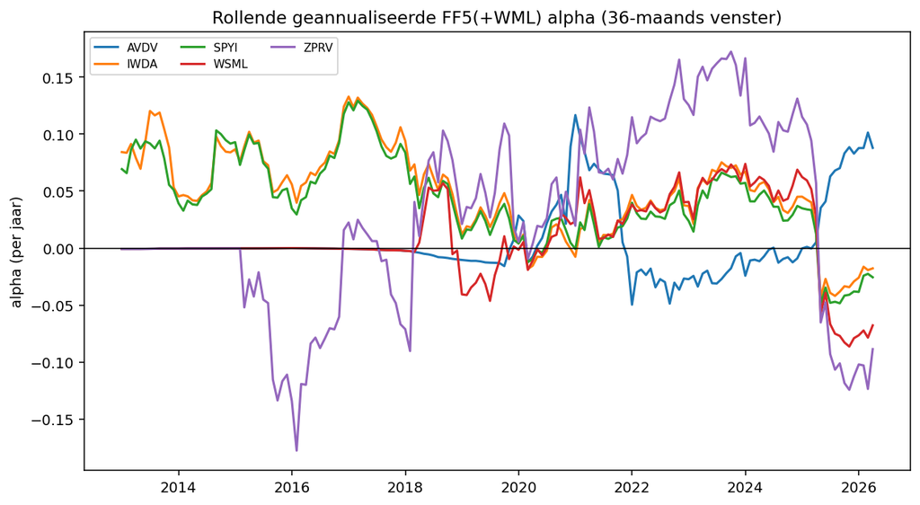

Rollende geannualiseerde FF5(+WML)-alpha per ETF.

De bèta’s vertellen het eigenlijke verhaal. De small-cap-value-fondsen laden positief op SMB en HML; de brede trackers liggen rond nul of licht negatief op HML (een groei-kanteling, want marktkapitalisatie weegt dure groeiaandelen zwaarder). Belangrijk: de ladingen zijn *niet constant* — ze ademen met de marktcyclus, wat bevestigt dat een tilt iets is dat je door de tijd moet kunnen volhouden.

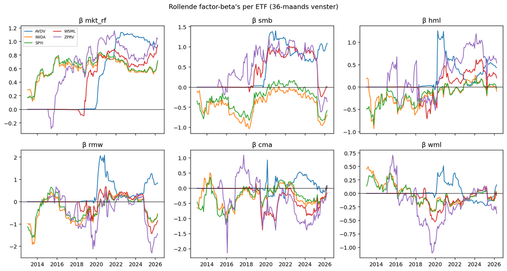

Rollende factor-bèta’s per ETF (36-maands venster).

Hetzelfde in Morningstar-stijlboxvorm: de horizontale as is de SMB-bèta (grootte), de verticale de HML-bèta (waarde). Het spoor van elk fonds toont de *drift* van zijn stijl; de dikke punt is de laatste positie.

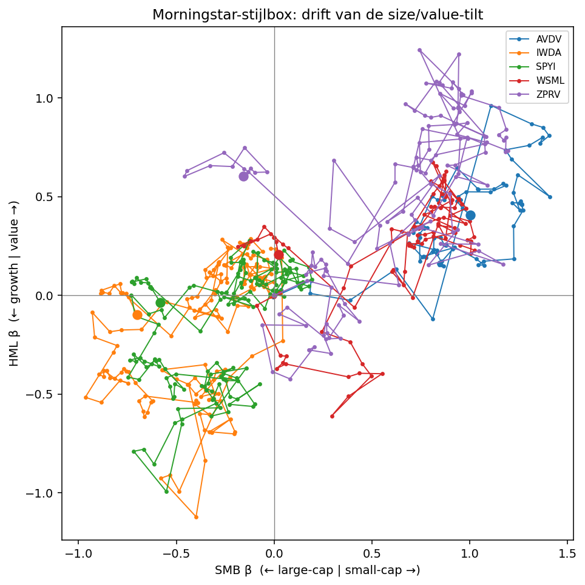

Stijlbox-drift: SMB-bèta versus HML-bèta door de tijd.

**Laatste 36-maands venster:**

| symbol | β SMB | β HML | β RMW | alpha p.j. | alpha t | n |
| --- | --- | --- | --- | --- | --- | --- |
| ZPRV | -0.36 | 0.54 | -1.43 | -8.9 % | -1.01 | 36 |
| SPYI | -0.58 | -0.04 | -0.58 | -2.6 % | -0.51 | 36 |
| IWDA | -0.69 | -0.09 | -0.54 | -1.8 % | -0.35 | 36 |
| WSML | 0 | 0.2 | -0.85 | -6.8 % | -1.09 | 36 |
| AVDV | 1.09 | 0.43 | 0.85 | +8.8 % | 2.56 | 36 |

## Krimpt de premie?

Een factorpremie is pas bruikbaar als ze blijft bestaan nadat iedereen ervan weet. McLean & Pontiff (2016) toonden dat de gemiddelde anomalie na publicatie ongeveer 58 % van haar rendement verliest: zodra een edge bekend is, arbitreren beleggers hem grotendeels weg. Swedroe & Berkin maken in *The Incredible Shrinking Alpha* (2e ed., 2020) hetzelfde punt voor de klassieke factoren — wat ooit alpha heette, is grotendeels bèta geworden, en zelfs die bèta-premie compresseert.

We toetsen dit op de lange `developed`-FF-reeks (1990–2026, niet het korte ETF-venster) door elke factor in drie deelperioden te splitsen: de volledige steekproef, het deel ná de publicatie van de seminale paper, en de laatste twintig jaar.

| factor | volledig | na publicatie | laatste 20 j | t volledig | t recent | krimp |
| --- | --- | --- | --- | --- | --- | --- |
| mkt_rf | +6.5 % | +6.5 % | +7.6 % | 2.6 | 2.2 | -18 % |
| smb | +0.1 % | -0.0 % | -1.6 % | 0 | -1.3 | — |
| hml | +3.3 % | +3.4 % | +0.5 % | 2.2 | 0.3 | 85 % |
| rmw | +3.8 % | +2.5 % | +3.3 % | 4.4 | 3.4 | 13 % |
| cma | +2.4 % | +0.3 % | +1.1 % | 2.1 | 0.8 | 53 % |
| wml | +6.6 % | +6.5 % | +4.1 % | 3.1 | 1.6 | 38 % |

Het patroon is ondubbelzinnig. De waardepremie (HML) is het schoolvoorbeeld: ruim positief en significant over de hele reeks, maar de laatste twintig jaar vrijwel verdampt — een krimp van ~85 %, met een t-statistiek die door de significantiegrens zakt. CMA en WML krimpen eveneens fors. SMB is een apart geval: de size-premie was over de hele `developed`-steekproef al nauwelijks van nul te onderscheiden, zodat “krimp” hier geen betekenisvol getal oplevert (vandaar het streepje) — een resultaat dat op zich al veelzeggend is. RMW (winstgevendheid) houdt het relatief het best vol.

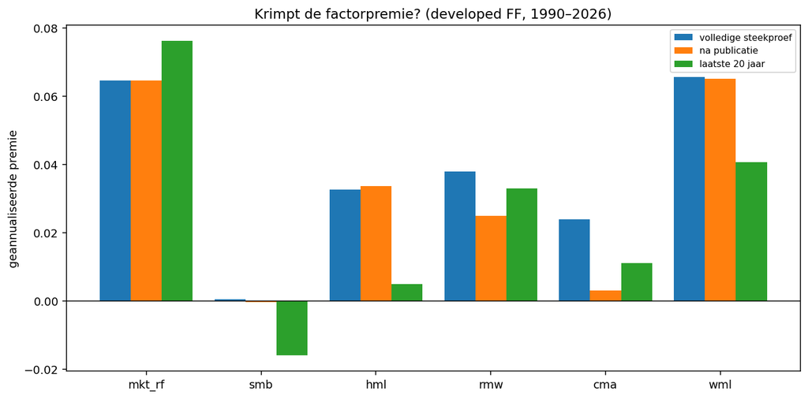

Geannualiseerde premie per deelperiode.

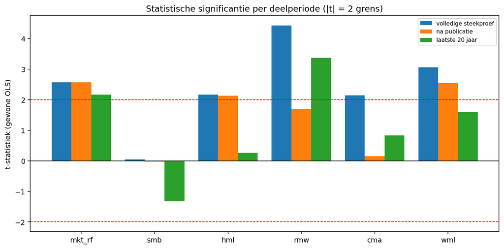

t-statistiek per deelperiode; de rode lijnen zijn de |t| = 2-significantiegrens.

Twee kanttekeningen houden dit eerlijk. Ten eerste overschat de gewone-OLS- t-statistiek de significantie (zie hoofdstuk 2); de werkelijke recente significantie is dus eerder nóg zwakker dan de grafiek suggereert. Ten tweede is de `developed`-reeks korter en breder dan de US-only reeks uit de oorspronkelijke papers — de gepubliceerde kolom in hoofdstuk 2 dient als teken-ijkpunt, niet als exacte benchmark. De richting blijft overeind: de premies die factorbeleggen verkopen, zijn na publicatie aanzienlijk gekrompen.

## De kostenbrug voor een Belgische belegger

Stel dat een factorpremie overeind blijft. Dan resteert de vraag die Sharpe (1991) al stelde: hoeveel ervan houd je nog over? Een brutopremie is een academisch begrip; een Belgische particulier betaalt lopende kosten, taksen en handelskosten die de premie afromen vóór ze zijn portefeuille bereikt.

We bouwen de brug op met de geannualiseerde HML-premie uit de gepubliceerde literatuur als bruto vertrekpunt en trekken er, post voor post, de reële kosten van een buy-and-hold-belegger van af:

- **Lopende kosten (TER)** — de jaarlijkse fondskost, per fonds uit de KIID.
- **Beurstaks (TOB)** — eenmalig bij aankoop, uitgesmeerd over de beleggingshorizon; tarief uit `shared/be_tax/data/tob.yaml` (een EER-geregistreerde accumulerende UCITS-ETF betaalt 0,12 %, een niet-EER fonds zoals AVDV 0,35 %).
- **Spread × turnover** — de halve bid-ask-spread toegepast op de jaarlijkse omloopsnelheid van de indexmethodologie (small-cap-value roteert meer dan een brede tracker).
- **Dividendlek** — buitenlandse bronheffing die het fonds niet kan recupereren; structureel, en identiek voor de tilt en zijn benchmark, maar het hoort in het absolute plaatje.

| etf | bruto premie | TER | TOB p.j. | spread×turnover | dividendlek | netto alpha |
| --- | --- | --- | --- | --- | --- | --- |
| ZPRV | 4.03 % | 0.30 % | 0.01 % | 0.02 % | 0.25 % | 3.46 % |
| AVDV | 4.03 % | 0.36 % | 0.02 % | 0.02 % | 0.25 % | 3.39 % |
| AVWS | 4.03 % | 0.39 % | 0.01 % | 0.02 % | 0.25 % | 3.37 % |

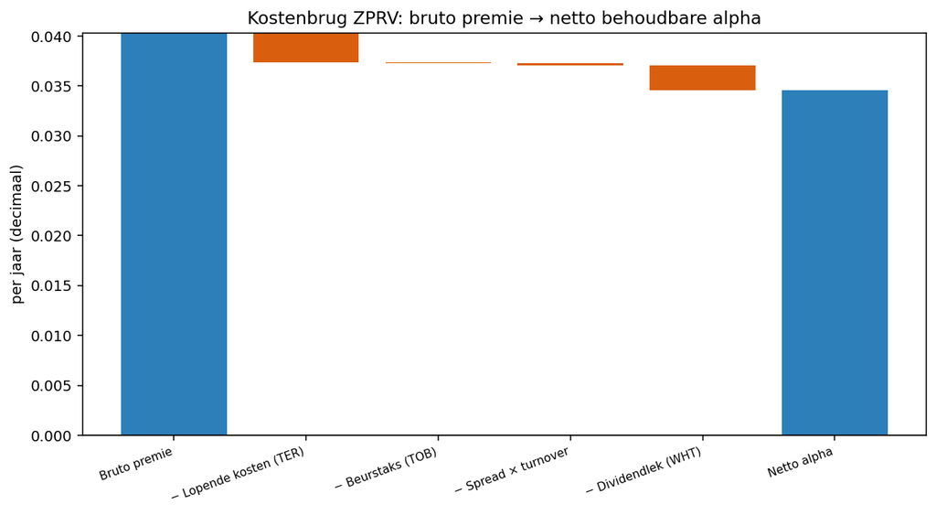

Kostenbrug ZPRV: van brutopremie naar netto behoudbare alpha.

De boodschap is niet dat de kosten de premie volledig opeten — bij een brutopremie van ~4 % per jaar en kosten in de orde van 0,6–0,7 % blijft er netto nog iets over. De boodschap is dat de marge dun en fragiel is. Combineer deze afroming met de bevinding uit hoofdstuk 4 — dat dezelfde HML-premie de laatste twintig jaar met ~85 % gekrompen is — en de netto behoudbare alpha kan in een ongunstig regime makkelijk negatief worden. Sharpe’s rekenkunde laat geen ruimte voor wishful thinking: elke kostenpost is zeker, de premie niet.

## Conclusie: tilt alleen wat u kunt volhouden

*Krimpt de premie?* Ja, en fors. Op de lange `developed`-reeks is de waardepremie de laatste twintig jaar met ~85 % gekrompen en niet langer statistisch overtuigend; momentum en investment volgen hetzelfde pad. Dit is precies het McLean-Pontiff- en Swedroe-patroon: na publicatie verdwijnt het grootste deel van de edge.

*Wat blijft er netto over?* Bij een viertal procent brutopremie en zes à zeven tienden procent kosten blijft er een dunne, fragiele marge — die in een ongunstig regime, gecombineerd met premiekrimp, makkelijk negatief wordt. Sharpe’s rekenkunde geeft geen krediet: kosten zijn zeker, premies niet.

De praktische gevolgtrekking is geen verbod op factorbeleggen, maar een voorwaarde. Een tilt is verdedigbaar voor wie de tracking error — lange, zenuwslopende periodes van onderprestatie tegenover de markt — emotioneel én financieel kan uitzitten, en wie de kosten laag houdt. Wie dat niet kan, verliest meer aan paniekverkopen op de bodem dan de premie ooit zou opleveren. Dat is exact de boodschap die de herbruikbare `FACTOR_INVESTING_BLURB` in de klantrapporten nu, met bronnen onderbouwd, uitdraagt: factorbeleggen is geen gratis meerrendement, maar een risicopremie die je alleen incasseert als je hem kunt volhouden.